# Krs

Курсовая работа по дисциплине «Технологии машинного обучения»

1. **Поиск и выбор набора данных для построения моделей машинного обучения. На основе выбранного набора данных студент должен построить модели машинного обучения для решения или задачи классификации, или задачи регрессии.**
2. **Проведение разведочного анализа данных. Построение графиков, необходимых для понимания структуры данных. Анализ и заполнение пропусков в данных.**
3. **Выбор признаков, подходящих для построения моделей. Кодирование категориальных признаков Масштабирование данных. Формирование вспомогательных признаков, улучшающих качество моделей.**
4. **Проведение корреляционного анализа данных. Формирование промежуточных выводов о возможности построения моделей машинного обучения. В зависимости от набора данных, порядок выполнения пунктов 2, 3, 4 может быть изменен.**
5. Выбор метрик для последующей оценки качества моделей. Необходимо выбрать не менее трех метрик и обосновать выбор.
6. Выбор наиболее подходящих моделей для решения задачи классификации или регрессии. Необходимо использовать не менее пяти моделей, две из которых должны быть ансамблевыми.
7. Формирование обучающей и тестовой выборок на основе исходного набора данных.
8. Построение базового решения (baseline) для выбранных моделей без подбора гиперпараметров. Производится обучение моделей на основе обучающей выборки и оценка качества моделей на основе тестовой выборки.
9. Подбор гиперпараметров для выбранных моделей. Рекомендуется использовать методы кросс-валидации. В зависимости от используемой библиотеки можно применять функцию GridSearchCV, использовать перебор параметров в цикле, или использовать другие методы.
10. Повторение пункта 8 для найденных оптимальных значений гиперпараметров. Сравнение качества полученных моделей с качеством baseline-моделей.
11. Формирование выводов о качестве построенных моделей на основе выбранных метрик. Результаты сравнения качества рекомендуется отобразить в виде графиков и сделать выводы в форме текстового описания. Рекомендуется постройение графиков обучения и валидации, влияния значений гиперпарметров на качество моделей и т.д.

```python
import numpy as np
import pandas as pd
```

# ЗАГРУЗКА ДАННЫХ

```python
data = pd.read_csv('data.csv')
data.head()
```

|  | date | price | bedrooms | bathrooms | sqft_living | sqft_lot | floors | waterfront | view | condition | sqft_above | sqft_basement | yr_built | yr_renovated | street | city | statezip | country |
| --- | --- | --- | --- | --- | --- | --- | --- | --- | --- | --- | --- | --- | --- | --- | --- | --- | --- | --- |
| 0 | 2014-05-02 00:00:00 | 313000.0 | 3.0 | 1.50 | 1340 | 7912 | 1.5 | 0 | 0 | 3 | 1340 | 0 | 1955 | 2005 | 18810 Densmore Ave N | Shoreline | WA 98133 | USA |
| 1 | 2014-05-02 00:00:00 | 2384000.0 | 5.0 | 2.50 | 3650 | 9050 | 2.0 | 0 | 4 | 5 | 3370 | 280 | 1921 | 0 | 709 W Blaine St | Seattle | WA 98119 | USA |
| 2 | 2014-05-02 00:00:00 | 342000.0 | 3.0 | 2.00 | 1930 | 11947 | 1.0 | 0 | 0 | 4 | 1930 | 0 | 1966 | 0 | 26206-26214 143rd Ave SE | Kent | WA 98042 | USA |
| 3 | 2014-05-02 00:00:00 | 420000.0 | 3.0 | 2.25 | 2000 | 8030 | 1.0 | 0 | 0 | 4 | 1000 | 1000 | 1963 | 0 | 857 170th Pl NE | Bellevue | WA 98008 | USA |
| 4 | 2014-05-02 00:00:00 | 550000.0 | 4.0 | 2.50 | 1940 | 10500 | 1.0 | 0 | 0 | 4 | 1140 | 800 | 1976 | 1992 | 9105 170th Ave NE | Redmond | WA 98052 | USA |

Убираем лишние столбцы, на которые при обучении мы обращать внимания не будем

```python
data = data.drop(['country','statezip','waterfront','date','city','street'], axis=1)
```

```python
data.head()
```

|  | price | bedrooms | bathrooms | sqft_living | sqft_lot | floors | view | condition | sqft_above | sqft_basement | yr_built | yr_renovated |
| --- | --- | --- | --- | --- | --- | --- | --- | --- | --- | --- | --- | --- |
| 0 | 313000.0 | 3.0 | 1.50 | 1340 | 7912 | 1.5 | 0 | 3 | 1340 | 0 | 1955 | 2005 |
| 1 | 2384000.0 | 5.0 | 2.50 | 3650 | 9050 | 2.0 | 4 | 5 | 3370 | 280 | 1921 | 0 |
| 2 | 342000.0 | 3.0 | 2.00 | 1930 | 11947 | 1.0 | 0 | 4 | 1930 | 0 | 1966 | 0 |
| 3 | 420000.0 | 3.0 | 2.25 | 2000 | 8030 | 1.0 | 0 | 4 | 1000 | 1000 | 1963 | 0 |
| 4 | 550000.0 | 4.0 | 2.50 | 1940 | 10500 | 1.0 | 0 | 4 | 1140 | 800 | 1976 | 1992 |

# АНАЛИЗ

Рынки недвижимости, такие как рынки в Сиднее и Мельбурне, предоставляют аналитикам данных интересную возможность для анализа и прогнозирования движения цен на недвижимость. Прогнозирование цен на недвижимость становится все более важным и выгодным. Цены на недвижимость являются хорошим индикатором как общего состояния рынка, так и экономического состояния страны. Учитывая предоставленные данные, мы обсуждаем большой набор записей о продажах недвижимости, хранящихся в неизвестном формате и с неизвестными проблемами качества данных.

**Датасет содержит:**  
date  
price  
bedrooms  
bathrooms  
sqft_living  
sqft_lot  
floors  
waterfront  
view  
condition  
sqft_above  
sqft_basement  
yr_built  
yr_renovated  
street  
city  
statezip  
country

**Целевой признак:**

1. price

```python
print(data.shape)
```

```
(4600, 12)
```

```python
print(data.info())
```

```
<class 'pandas.core.frame.DataFrame'>
RangeIndex: 4600 entries, 0 to 4599
Data columns (total 12 columns):
price            4600 non-null float64
bedrooms         4600 non-null float64
bathrooms        4600 non-null float64
sqft_living      4600 non-null int64
sqft_lot         4600 non-null int64
floors           4600 non-null float64
view             4600 non-null int64
condition        4600 non-null int64
sqft_above       4600 non-null int64
sqft_basement    4600 non-null int64
yr_built         4600 non-null int64
yr_renovated     4600 non-null int64
dtypes: float64(4), int64(8)
memory usage: 431.3 KB
None
```

```python
objectTypeData = data.select_dtypes(include = ['object']) # Включить в дату все колонки типа "object"
listOfObjectTypeData = objectTypeData.columns.tolist()

for column in listOfObjectTypeData:
    data[column] = data[column].astype('category') # И сетим вместо типа object тип category, дальше будет проще кодировать
```

```python
print(data.info())
```

```
<class 'pandas.core.frame.DataFrame'>
RangeIndex: 4600 entries, 0 to 4599
Data columns (total 12 columns):
price            4600 non-null float64
bedrooms         4600 non-null float64
bathrooms        4600 non-null float64
sqft_living      4600 non-null int64
sqft_lot         4600 non-null int64
floors           4600 non-null float64
view             4600 non-null int64
condition        4600 non-null int64
sqft_above       4600 non-null int64
sqft_basement    4600 non-null int64
yr_built         4600 non-null int64
yr_renovated     4600 non-null int64
dtypes: float64(4), int64(8)
memory usage: 431.3 KB
None
```

# ЗАМЕНА ПРОПУСКОВ

**Проверим на пропуски**

```python
print(data.isnull().sum())
```

```
price            0
bedrooms         0
bathrooms        0
sqft_living      0
sqft_lot         0
floors           0
view             0
condition        0
sqft_above       0
sqft_basement    0
yr_built         0
yr_renovated     0
dtype: int64
```

**Наш датасет не имеет null элементов**

Если бы были пропуски, то я бы использовал заполнение числовых пропусков медианными значениями

```python
objectTypeData = data.select_dtypes(include = ['int64', 'float64']) # Только числовые значения
listOfObjectTypeData = objectTypeData.columns.tolist()

for column in listOfObjectTypeData:
    data[column] = data[column].fillna(data[column].median())
    # Функция median вычисляет медианные значения в столбце
    # Функция fillna заменяет NA/NAN на значение
```

Если бы были пропуски в категориальных значениях, то я бы nan и null заменил константным методом

```python
objectTypeData = data.select_dtypes(include = ['category'])
listOfObjectTypeData = objectTypeData.columns.tolist()

for column in listOfObjectTypeData:
    data[column] = data[column].fillna(data[column].describe(include=['category'])['top'])
```

# МАСШТАБИРОВАНИЕ

```python
from sklearn.preprocessing import MinMaxScaler
import matplotlib.pyplot as plt
```

Для адекватного отображения графиков нормазируем наши значения

```python
data.head()
```

|  | price | bedrooms | bathrooms | sqft_living | sqft_lot | floors | view | condition | sqft_above | sqft_basement | yr_built | yr_renovated |
| --- | --- | --- | --- | --- | --- | --- | --- | --- | --- | --- | --- | --- |
| 0 | 313000.0 | 3.0 | 1.50 | 1340 | 7912 | 1.5 | 0 | 3 | 1340 | 0 | 1955 | 2005 |
| 1 | 2384000.0 | 5.0 | 2.50 | 3650 | 9050 | 2.0 | 4 | 5 | 3370 | 280 | 1921 | 0 |
| 2 | 342000.0 | 3.0 | 2.00 | 1930 | 11947 | 1.0 | 0 | 4 | 1930 | 0 | 1966 | 0 |
| 3 | 420000.0 | 3.0 | 2.25 | 2000 | 8030 | 1.0 | 0 | 4 | 1000 | 1000 | 1963 | 0 |
| 4 | 550000.0 | 4.0 | 2.50 | 1940 | 10500 | 1.0 | 0 | 4 | 1140 | 800 | 1976 | 1992 |

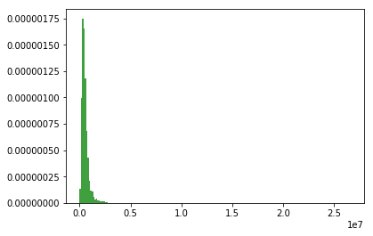

```python
plt.hist(data['price'], 200, density=1, facecolor='g', alpha=0.75)
# plt.xlabel('Кол-во провинностей')
# plt.ylabel('Отношение')
plt.show()
```

```python
data_x = data.loc[:, (data.columns != 'street') & (data.columns != 'city')]
listColumns = data_x.columns
min_max_scaler = MinMaxScaler()
x_scaled = min_max_scaler.fit_transform(data[listColumns])
dataset = pd.DataFrame(x_scaled, columns = listColumns)
for col in listColumns:
    data[col] = dataset[col]
```

```python
data.head()
```

|  | price | bedrooms | bathrooms | sqft_living | sqft_lot | floors | view | condition | sqft_above | sqft_basement | yr_built | yr_renovated |
| --- | --- | --- | --- | --- | --- | --- | --- | --- | --- | --- | --- | --- |
| 0 | 0.011771 | 0.333333 | 0.18750 | 0.073652 | 0.006775 | 0.2 | 0.0 | 0.50 | 0.107301 | 0.000000 | 0.482456 | 0.995531 |
| 1 | 0.089658 | 0.555556 | 0.31250 | 0.249051 | 0.007835 | 0.4 | 1.0 | 1.00 | 0.331858 | 0.058091 | 0.184211 | 0.000000 |
| 2 | 0.012862 | 0.333333 | 0.25000 | 0.118451 | 0.010534 | 0.0 | 0.0 | 0.75 | 0.172566 | 0.000000 | 0.578947 | 0.000000 |
| 3 | 0.015795 | 0.333333 | 0.28125 | 0.123766 | 0.006885 | 0.0 | 0.0 | 0.75 | 0.069690 | 0.207469 | 0.552632 | 0.000000 |
| 4 | 0.020684 | 0.444444 | 0.31250 | 0.119210 | 0.009186 | 0.0 | 0.0 | 0.75 | 0.085177 | 0.165975 | 0.666667 | 0.989076 |

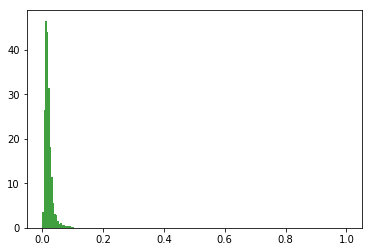

```python
plt.hist(data['price'], 200, density=1, facecolor='g', alpha=0.75)
# plt.xlabel('Кол-во провинностей')
# plt.ylabel('Отношение')
plt.show()
```

# КОДИРОВАНИЕ

Приводим наши оставшиеся категориальные признаки к числовому виду

```python
from sklearn.preprocessing import OneHotEncoder, LabelBinarizer
```

```python
objectTypeData = data.select_dtypes(include = ['category'])
listOfCategoryData = objectTypeData.columns.tolist()

for column in listOfCategoryData:
    mlb = LabelBinarizer()
    data[column] = mlb.fit_transform(data[column])
```

```python
data.head()
```

|  | price | bedrooms | bathrooms | sqft_living | sqft_lot | floors | view | condition | sqft_above | sqft_basement | yr_built | yr_renovated |
| --- | --- | --- | --- | --- | --- | --- | --- | --- | --- | --- | --- | --- |
| 0 | 0.011771 | 0.333333 | 0.18750 | 0.073652 | 0.006775 | 0.2 | 0.0 | 0.50 | 0.107301 | 0.000000 | 0.482456 | 0.995531 |
| 1 | 0.089658 | 0.555556 | 0.31250 | 0.249051 | 0.007835 | 0.4 | 1.0 | 1.00 | 0.331858 | 0.058091 | 0.184211 | 0.000000 |
| 2 | 0.012862 | 0.333333 | 0.25000 | 0.118451 | 0.010534 | 0.0 | 0.0 | 0.75 | 0.172566 | 0.000000 | 0.578947 | 0.000000 |
| 3 | 0.015795 | 0.333333 | 0.28125 | 0.123766 | 0.006885 | 0.0 | 0.0 | 0.75 | 0.069690 | 0.207469 | 0.552632 | 0.000000 |
| 4 | 0.020684 | 0.444444 | 0.31250 | 0.119210 | 0.009186 | 0.0 | 0.0 | 0.75 | 0.085177 | 0.165975 | 0.666667 | 0.989076 |

# КОРРЕЛЯЦИЯ

```python
import seaborn as sns
```

```python
def plot_corr_matrix(df,size=15):
    corr = df.corr().abs()
    fig, ax = plt.subplots(figsize=(size, size))
    ax.matshow(corr)
    plt.xticks(range(len(corr.columns)), corr.columns)
    plt.yticks(range(len(corr.columns)), corr.columns)
    plt.xticks(rotation=90)
    return corr
```

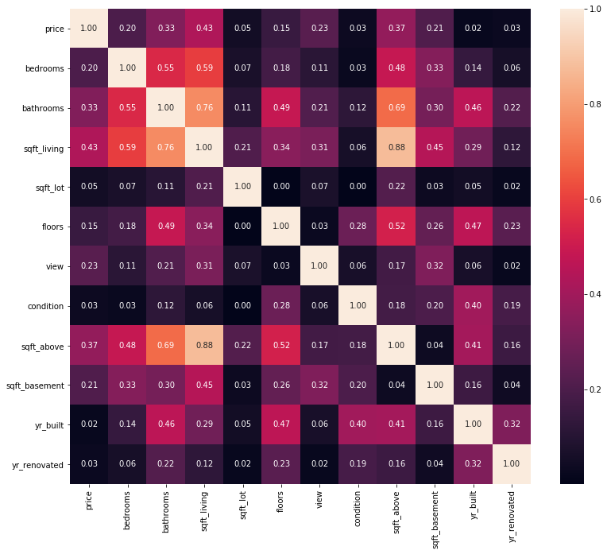

```python
fig, ax = plt.subplots(figsize=(13, 11))
sns.heatmap(data.corr(method='pearson').abs(), ax=ax, annot=True, fmt='.2f')
plt.yticks()
```

```python
data = data.drop(['sqft_above'], axis=1)
```

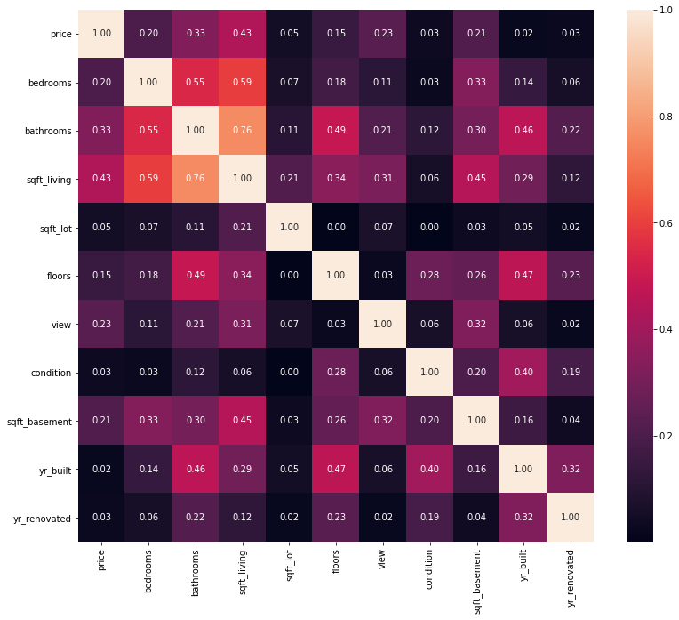

```python
fig, ax = plt.subplots(figsize=(13, 11))
sns.heatmap(data.corr(method='pearson').abs(), ax=ax, annot=True, fmt='.2f')
plt.yticks()
```

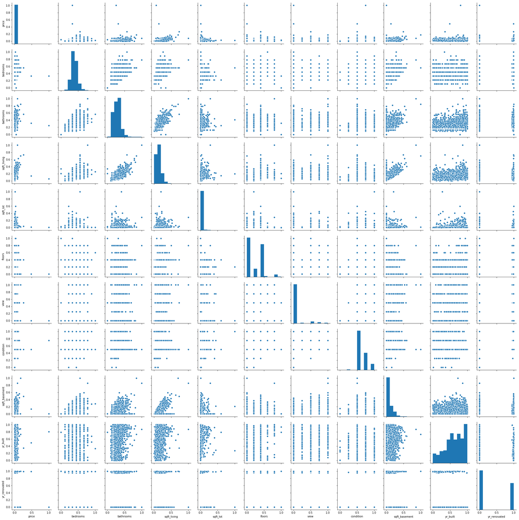

```python
sns.pairplot(data)
```

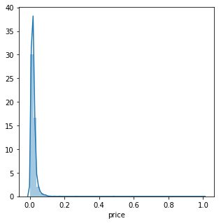

```python
# Плотность распределения данных
fig, ax = plt.subplots(figsize=(5,5))
sns.distplot(data['price'])
```

# ОБУЧЕНИЕ

ЦЕЛЬ: Y  
ОСТАЛЬНЫЕ ПАРАМЕТРЫ: X

```python
def statistics(test_Y, target):
    print("Средняя абсолютная ошибка:", mean_absolute_error(test_Y, target))   # Средняя абсолютная ошибка
    print("Средняя квадратичная ошибка:", mean_squared_error(test_Y, target))    # Средняя квадратичная ошибка
    print("Медианная абсолютная ошибка:", median_absolute_error(test_Y, target)) # Медианная абсолютная ошибка
```

## Разделение выборки

```python
from sklearn.model_selection import cross_val_score, cross_validate, train_test_split, GridSearchCV, RandomizedSearchCV, KFold, RepeatedKFold, LeaveOneOut, LeavePOut, ShuffleSplit, StratifiedKFold, learning_curve, validation_curve
from sklearn.neighbors import KNeighborsRegressor, KNeighborsClassifier
from sklearn.svm import SVC, NuSVC, LinearSVC, OneClassSVM, SVR, NuSVR, LinearSVR
from sklearn.tree import DecisionTreeRegressor
from sklearn.ensemble import RandomForestClassifier, RandomForestRegressor, AdaBoostRegressor
from sklearn.metrics import accuracy_score, mean_absolute_error, mean_squared_error, mean_squared_log_error, median_absolute_error, precision_score, recall_score, f1_score, classification_report, confusion_matrix, roc_curve, roc_auc_score
```

```python
data_x = data.loc[:, data.columns != 'price'] # Остальные параметры
data_y = data[['price']] # Целевой признак

data_X_train, data_X_test, data_Y_train, data_Y_test = train_test_split(
    data_x, data_y, test_size=0.3, random_state=1) # Тренировочная около 70%, а тестовая для поверки 30%
data_X_train.shape, data_X_test.shape
```

```
((3220, 10), (1380, 10))
```

- Метод k ближайших соседей
- SVM (метод опорных векторов)
- Решающие деревья
- RandomForestRegressor (Случайный лес)
- AdaBoost

## Метод ближайших соседей

```python
count_neighbors = 2
knr1 = KNeighborsRegressor(n_neighbors = count_neighbors)
knr1.fit(data_X_train, data_Y_train)
knr_target1 = knr1.predict(data_X_test)
print("Кол-во соседей:", count_neighbors)
statistics(data_Y_test, knr_target1)
```

```
Кол-во соседей: 2
Средняя абсолютная ошибка: 0.00833983659840795
Средняя квадратичная ошибка: 0.0005305242621792117
Медианная абсолютная ошибка: 0.005106713050018805
```

```python
n_range = np.array(range(2,51,4)) # Возможные кол-во соседей
massNeighbors = [{'n_neighbors': n_range}] # Форматируем под дальнейший ввод

clf_gs = GridSearchCV(KNeighborsRegressor(), massNeighbors, cv=5, scoring='neg_mean_absolute_error') # Перекрёстная проверка
clf_gs.fit(data_X_train, data_Y_train)

print("Лучший параметр n:", clf_gs.best_params_)
```

```
Лучший параметр n: {'n_neighbors': 10}
```

```python
count_neighbors = clf_gs.best_params_['n_neighbors']
knr2 = KNeighborsRegressor(n_neighbors = count_neighbors)
knr2.fit(data_X_train, data_Y_train)
knr_target2 = knr2.predict(data_X_test)
print("Кол-во соседей:", count_neighbors)
statistics(data_Y_test, knr_target2)
```

```
Кол-во соседей: 10
Средняя абсолютная ошибка: 0.006962347865653101
Средняя квадратичная ошибка: 0.00014466327591766624
Медианная абсолютная ошибка: 0.004576805189921026
```

## SVM (метод опорных векторов)

```python
svm1 = LinearSVR(max_iter=10000)
svm1.fit(data_X_train, data_Y_train)
svm_target1 = svm1.predict(data_X_test)
statistics(data_Y_test, svm_target1)
```

```
Средняя абсолютная ошибка: 0.0061004799995350335
Средняя квадратичная ошибка: 9.559368694432405e-05
Медианная абсолютная ошибка: 0.004265435195273842
```

## Решающие деревья

```python
tree1 = DecisionTreeRegressor(max_depth=2)
tree1.fit(data_X_train, data_Y_train)
tree_target1 = tree1.predict(data_X_test)
statistics(data_Y_test, tree_target1)
```

```
Средняя абсолютная ошибка: 0.007114938024239556
Средняя квадратичная ошибка: 0.00012021937731062798
Медианная абсолютная ошибка: 0.005255735238811584
```

# Ансамблевые модели

## RandomForestRegressor (Случайный лес)

```python
random1 = RandomForestRegressor(n_estimators=100)
random1.fit(data_X_train, data_Y_train)
random_target1 = random1.predict(data_X_test)
statistics(data_Y_test, random_target1)
```

```
Средняя абсолютная ошибка: 0.006850026388636243
Средняя квадратичная ошибка: 0.00031927546519070377
Медианная абсолютная ошибка: 0.004065153946604068
```

```python
tuned_parameters = {'n_estimators': [500, 700, 1000], 'max_depth': [None, 1, 2, 3]}

forest_search = GridSearchCV(RandomForestRegressor(), param_grid=tuned_parameters, cv=5, n_jobs=-1, verbose=1)
forest_search.fit(data_X_train, data_Y_train)

print(forest_search.best_params_)
```

```
Fitting 5 folds for each of 12 candidates, totalling 60 fits
```

```
[Parallel(n_jobs=-1)]: Using backend LokyBackend with 4 concurrent workers.
[Parallel(n_jobs=-1)]: Done  42 tasks      | elapsed:   36.2s
[Parallel(n_jobs=-1)]: Done  60 out of  60 | elapsed:   44.5s finished
```

```
{'max_depth': 3, 'n_estimators': 500}
```

```python
random2 = RandomForestRegressor(random_state=1, max_depth = 3, n_estimators = 700)
random2.fit(data_X_train, data_Y_train)
random_target2 = random2.predict(data_X_test)
statistics(data_Y_test, random_target2)
```

```
Средняя абсолютная ошибка: 0.006594391144138022
Средняя квадратичная ошибка: 0.00010427020986560978
Медианная абсолютная ошибка: 0.004935108895914839
```

## AdaBoost

```python
ab1 = AdaBoostRegressor(random_state=1, base_estimator = RandomForestRegressor(random_state=1, max_depth = 3, n_estimators = 500))
ab1.fit(data_X_train, data_Y_train)
ab_target1 = ab1.predict(data_X_test)
statistics(data_Y_test, ab_target1)
```

```
Средняя абсолютная ошибка: 0.007652890549484558
Средняя квадратичная ошибка: 0.00012600364642501087
Медианная абсолютная ошибка: 0.005725410248184235
```

```python
parameters = {'n_estimators': (1, 2, 5), 'base_estimator__max_depth': (1, 2, 3)}
ab_search = GridSearchCV(ab1, parameters)
ab_search.fit(data_X_train, data_Y_train)
print(ab_search.best_params_)
```

[output not shown]

[output cut: 20 more lines]

```
{'base_estimator__max_depth': 2, 'n_estimators': 1}
```

```python
ab2 = AdaBoostRegressor(random_state=1, base_estimator = RandomForestRegressor(random_state=1, max_depth = 2, n_estimators = 1))
ab2.fit(data_X_train, data_Y_train)
ab_target2 = ab2.predict(data_X_test)
statistics(data_Y_test, ab_target2)
```

```
Средняя абсолютная ошибка: 0.008966080597761808
Средняя квадратичная ошибка: 0.0002614738121260098
Медианная абсолютная ошибка: 0.005908291310618287
```

# РЕЗУЛЬТАТЫ/СРАВНЕНИЕ

```python
d1 = [   {"model": "МБС", "mean_absolute_error" : mean_absolute_error(data_Y_test, knr_target2)},
         {"model": "SVM", "mean_absolute_error" : mean_absolute_error(data_Y_test, svm_target1)},
         {"model": "DTC", "mean_absolute_error" : mean_absolute_error(data_Y_test, tree_target1)},
         {"model": "RFR", "mean_absolute_error" : mean_absolute_error(data_Y_test, random_target2)},
         {"model": "AB",  "mean_absolute_error" : mean_absolute_error(data_Y_test, ab_target1)}        ]

d2 = [   {"model": "МБС", "mean_squared_error" : mean_squared_error(data_Y_test, knr_target2)},
         {"model": "SVM", "mean_squared_error" : mean_squared_error(data_Y_test, svm_target1)},
         {"model": "DTC", "mean_squared_error" : mean_squared_error(data_Y_test, tree_target1)},
         {"model": "RFR", "mean_squared_error" : mean_squared_error(data_Y_test, random_target2)},
         {"model": "AB",  "mean_squared_error" : mean_squared_error(data_Y_test, ab_target1)}        ]

d3 = [   {"model": "МБС", "median_absolute_error" : median_absolute_error(data_Y_test, knr_target2)},
         {"model": "SVM", "median_absolute_error" : median_absolute_error(data_Y_test, svm_target1)},
         {"model": "DTC", "median_absolute_error" : median_absolute_error(data_Y_test, tree_target1)},
         {"model": "RFR", "median_absolute_error" : median_absolute_error(data_Y_test, random_target2)},
         {"model": "AB",  "median_absolute_error" : median_absolute_error(data_Y_test, ab_target1)}        ]

dd1 = pd.DataFrame(d1)
dd2 = pd.DataFrame(d2)
dd3 = pd.DataFrame(d3)
```

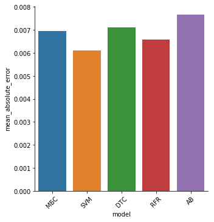

```python
gisto = sns.factorplot(x='model'
                   ,y= 'mean_absolute_error'
                   ,data=dd1
                   ,kind='bar'

                   )
gisto.set_xticklabels(rotation=45)
```

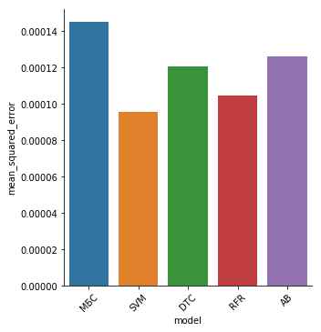

```python
gisto = sns.factorplot(x='model'
                   ,y= 'mean_squared_error'
                   ,data=dd2
                   ,kind='bar'

                   )
gisto.set_xticklabels(rotation=45)
```

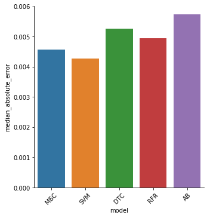

```python
gisto = sns.factorplot(x='model'
                   ,y= 'median_absolute_error'
                   ,data=dd3
                   ,kind='bar'

                   )
gisto.set_xticklabels(rotation=45)
```

### Во всех параметрах побеждает SVM (метод опорных векторов)!